### Major libraries that have been used in this tutorial

```python
import math
import sympy
import scipy
import control
import numpy as np
from scipy import signal
from matplotlib import pyplot as plt
```

# Introduction to Signals and systems in python

Welcome to Signals and systems!

In this simple tutorial, we will learn about python3's basic commands and methods that we will use them for Signal processing, Dynamic systems and control theory.

Consider that this tutorial uses Python 3.7.0

# Note

This tutorial has been created by $\href{https://hnxj.github.io}{Hamed \: Nejat}$ for Signals and systems course of $\href{https://ee.sharif.edu}{Electrical \: Engineering \: Department \: of \: Sharif \: University \: of \: Technology}$, with major help of official documents of Numpy, Scipy, Matplotlib, Control and Sympy. special thanks to all other python developers, this tutorial is free to use.

## Recommended : Anaconda with Python3.7 Download links:

Anaconda is easy to use, hence pure python is also suitable for this course

Windows (x64/x86) (~490MB) : https://repo.anaconda.com/archive/Anaconda3-2019.07-Windows-x86_64.exe

for MacOS (~650MB) : https://repo.anaconda.com/archive/Anaconda3-2019.07-MacOSX-x86_64.pkg

for Linux (~510MB) : https://repo.anaconda.com/archive/Anaconda3-2019.07-Linux-x86_64.sh

## Virtual environments:

In anaconda prompt, write:

-->conda create -n env_name python=3.7

Then everytime you want to code for this course, write:

-->conda activate evn_name

And when you dont want to use this env:

-->conda deactivate env_name

for anaconda users:

-->conda install jupyter

for main python users:

-->pip install

## Run Jupyter notebook:

Open Anaconda prompt, one of the ways is to search "Anaconda prompt" in windows search.

After opening of Anaconda Prompt, Enter:

-->jupyter lab

Then, you are in jupyter environment. click on file tab, then click on new notebook.

## Run Spyder scientific IDE

On cmd/terminal, install spyder using this commands:

-->conda install spyder

To run:

-->spyder

#### Contact

For more questions about tutorial class or homeworks:

contact us : hamednejat7@gmail.com

# 0: Introduction to python

### 0.1: Basic commands

```
EXAMPLES:

In the begining of almost every programming language, we try to print a text or a number. python is easy to
start! here are some examples of printing variables:
```

### Input/Output (I/O)

```python
print("You will never walk alone") # Raw string
print("There is" + " a " + "GoldenSky :)" # Multi strings
    " Walk on", "trough the rain") # multi line
```

```
You will never walk alone
There is a GoldenSky :) Walk on trough the rain
```

```python
a = int(input("Enter int number"))
b = float(input("enter float"))
s = str(input("Enter string"))

print(a, b, s)
```

```
12653451253 123.123 YNWA
```

```python
print(6) # Integers
print(-7) # Integers
print(18.0) # Floats
print("18.0 " + str(-32.4353)) # Numbers to string
print(float("18.34") + 32.4353) # Strings to number
print(float("-18.34") + 32.4353) # Signed strings to number, Sign is included in
                                 # number while it was converted from string to number!
```

```
6
-7
18.0
18.0 -32.4353
50.7753
14.095299999999998
```

```python
print("First number: {}, Second number: {} and so on ...".format(4.01, 3.98))

print ('%.2f'%(11.1725612)) # 2-digit precision, rounded down because 11.1725612 < 11.175
print ('%.2f'%(11.1775612)) # 2-digit presicion rounded up because 11.1775612 > 11.175

print('%.5f'%(float("18.34") + 32.4353)) # Strings to number, 5-digit precision
print('%.3f'%(float("-18.34") + 32.4353)) # Signed strings to number, 3-digit precision

print('%f %d %s'%(11.13, 11.13, 11.13)) # printing float, integer and string in same command.
print('%f'%(1323.12312312312)) # NOTE!: default float precision is 6-digits
```

```
First number: 4.01, Second number: 3.98 and so on ...
11.17
11.18
50.77530
14.095
11.130000 11 11.13
1323.123123
```

### 0.2: Some data type and variable assignment

#### 0.2.1: integer, float, string, char

```python
a = 4 # integer
b = -5.12 # float
c = "Estereeng" # string

# char is almost same with str in python, except char array in classes
d = chr(113) # <C: char> = chr(<I: integer>) method returns the character that has ascii=I
e = ord('q') # <I: integer> = ord(<C: char>) method returns the ascii that char=C

print("\nType of a is :", type(a), "a :", a,
      "\nType of b is :", type(b), "b :", b,
      "\nType of c is :", type(c), "c :", c,
      "\nType of d is :", type(d), "d :", d,
      "\nType of e is :", type(e), "d :", e)
```

```
Type of a is : <class 'int'> a : 4
Type of b is : <class 'float'> b : -5.12
Type of c is : <class 'str'> c : Estereeng
Type of d is : <class 'str'> d : q
Type of e is : <class 'int'> d : 113
```

#### 0.2.2: Dictionary

```python
e = dict() # dict :: e[<Key>] = <Val>
e["asd"] = 12 # assigning num to string key
e[1] = a # integer to integer
e[b] = 'L' # char (string) to float

print("\nType of e is :", type(e), "\n e :", e)
print("e[\"asd\"] is : ", e["asd"])
```

```
Type of e is : <class 'dict'>
 e : {'asd': 12, 1: 4, -5.12: 'L'}
e["asd"] is :  12
```

#### 0.2.3: List

```python
f = list() # alternate for list / f = [1, 1.1, list]
f.append(1) # appending an integer
f.append(1.1) # appending a float

f.append("paganini") # appending a string
f.append(e) # appending a dictionary!
print("\nType of e is :", type(f), "e :", f)

f.pop(2) # pop 2nd element
print("\nType of e is :", type(f), "e :", f)
f.pop() # pop last element
print("\nType of e is :", type(f), "e :", f)
```

```
Type of e is : <class 'list'> e : [1, 1.1, 'paganini', {'asd': 12, 1: 4, -5.12: 'L'}]

Type of e is : <class 'list'> e : [1, 1.1, {'asd': 12, 1: 4, -5.12: 'L'}]

Type of e is : <class 'list'> e : [1, 1.1]
```

#### 0.2.4: Set

```python
f = set() # alternate for list / f = [1, 1.1, list]
f.add(1) # add an integer to the set
f.add(1.1) # appending a float
f.add(2)
f.add(-1)

f.add("vivaldi") # appending a string
f.add("antonio")
# f.add(e) # appending a dictionary!
print("\nType of e is :", type(f), "e :", f)

f.remove("antonio") # remove one existing element

try: # prevents unexcepted errors and interrupts in program
    f.remove("bach") # key is not in the set
except KeyError:
    print("\nKey is not in the set")
except:
    print("Unknown error")

print("\nType of e is :", type(f), "e :", f)
f.pop() # pop last element
print("\nType of e is :", type(f), "e :", f)
```

```
Type of e is : <class 'set'> e : {'vivaldi', 1, 2, 1.1, 'antonio', -1}

Key is not in the set

Type of e is : <class 'set'> e : {'vivaldi', 1, 2, 1.1, -1}

Type of e is : <class 'set'> e : {1, 2, 1.1, -1}
```

## 0.3: Computation

In this subsection, we will do some maths computations and evaluate errors.

```python
import math
import numpy as np

a = 12.250
b = 27.601
c = a * b
d = a / b

print(a, b, c, d)
```

```
12.25 27.601 338.11225 0.443824499112351
```

```python
a = 3.131
b = 13.313
c = a ** b # a power b
d = np.sqrt(b) # radical b

print(a, b, c, d)
```

```
3.131 13.313 3972177.79380536 3.6486983980592314
```

```python
a = 3.131
b = np.sin(a) # numpy sinus; is radian based
c = np.cos(a) # numpy cosinus; is radian based
d = np.exp(c) # exponential

print(a, b, c, d)
```

```
3.131 0.010592455500673467 -0.9999438983695367 0.3679000803868474
```

```python
a = -3.131 + 4.023j # complex number
b = np.sin(a) # numpy sinus; is radian based
c = np.cos(a) # numpy cosinus; is radian based
d = np.exp(c) # exponential

print(a, b, c, d)
```

```
(-3.131+4.023j) (-0.29598688665547973-27.92371377790813j) (-27.941611960486863+0.2957972903163078j) (7.011789697864798e-13+2.1367541336939334e-13j)
```

## 0.4: Loop and Condition

```python
import numpy as np
first = -4
last = 6
step = 2
cnt = 0.5

np_array1 = np.array([1, 0.7, -4, 2.0 + 2.0j, -0.5j])
np_array2 = np.array([[1, 2], [0.5j, -2], [4.0, 0.3j]])
```

#### 0.4.1: For loops

```python
for i in range(first, last, step): # ranged loop
    print(i**2.5)

for j in np_array1: # structured loop
    print(j)

for i, j in np_array2: # structured double loop
    print(i, j)
```

[output not shown]

```python
for i in range(7):
    print(i)
```

```
0
1
2
3
4
5
6
```

#### 0.4.2: While loops

```python
while cnt < 10:
    cnt *= 2.7
    print(cnt)
```

```
1.35
3.6450000000000005
9.841500000000002
26.572050000000008
```

#### 0.4.3: If conditions

```python
if step > 10:
    pass # the command that does nothing!
    # the code
elif step == 10: # Else If equivalent
    pass
    # the code
elif step == 9:
    quit() # Exit from the code or program !
else: # otherwise
    print("Nothing else matters")
```

```
Nothing else matters
```

## 0.5: Functions

```python
import numpy as np

# Basic recursive function
def gcd(a, b): # Greatest Common Divisor (GCD)
    if b > a:
        (a, b) (b, a) # nice swap in Python!
    if b == 0:
        return a
    return gcd(b, a%b)


R = 14
a = -1
u = lambda x : (x + abs(x))/2
f = lambda x : u(x) * (np.exp(3*x) + 3)


print(gcd(2436, 504))
print(f(1.2 + 1.0j), f(-1 - 0.01j), u(1), u(0.0), u(-1))

# IMPORTANT NOTE: Python has recursion limit, default recursion limit is 1000.
# you can change it by setrecursionlimit(<New Limit>)
import sys
sys.setrecursionlimit(10000)
```

```
84
(-48.47656220326329-9.483349516957443j) (6.877527054236574e-05-0.015248860663103969j) 1.0 0.0 0.0
```

```python
# Void function
def say_hello():
    print("Hello World :]")
    return # void return


say_hello()
```

```
Hello World :]
```

```python
# lambda function
hemographic1 = lambda x : (2 * x + 4) / (3 * x - 1)
print(hemographic1(4))
```

```
1.0909090909090908
```

## 1: Statistic and probabilistic computation

### 1.1: Random distributions and numbers

np.random is numpy's random variables and distributions sub-library.

```python
a = np.random.rand(5) # 10 random numbers uniformly between 0-1
b = np.random.randn(1000) # 1000 Gaussian standard distributed random numbers with mean = 0, std = 1
c = np.random.randint(-3, 14, 10) # 10 random integers between -3 and 13
d = np.random.gamma(2.5, 1, [2, 2]) # beta, gumbel, ... other distributions are available

print(a)
print(np.mean(b))
print(np.var(b))
print(c)
print(d)
```

```
[0.72043503 0.42271848 0.34518329 0.52325653 0.95223927]
0.0489575868952785
0.9714511651099623
[13  5  2  5  7  8  9 -1 -1  9]
[[0.52462323 1.44135035]
 [3.56640445 7.56055784]]
```

### 1.2: Stats and statistic variables

numpy has built-in important statistic functions, In the plotting part we will show simple statistical plotting

```python
import numpy as np

interval_first = 0
interval_last = 10
step = 2
amount = 33

e = np.arange(interval_first, interval_last, step) # equivalent to matlab's i:j with step
f = np.linspace(interval_first, interval_last, amount) # Splits line space between 1 and 10 into 25 numbers
g = np.mean(e)
h = np.var(f)

i = np.std(f)
j = np.max(e)
k = np.min(f)
l = np.median(e)

print(e)
print(f)
print(len(e)) # returns length of structure
print(len(f)) # returns length of structure

print(g, h, i)
print(j, k, l)
```

```
[0 2 4 6 8]
[ 0.      0.3125  0.625   0.9375  1.25    1.5625  1.875   2.1875  2.5
  2.8125  3.125   3.4375  3.75    4.0625  4.375   4.6875  5.      5.3125
  5.625   5.9375  6.25    6.5625  6.875   7.1875  7.5     7.8125  8.125
  8.4375  8.75    9.0625  9.375   9.6875 10.    ]
5
33
4.0 8.854166666666666 2.9755951785595207
8 0.0 4.0
```

# 2: Visualization and plotting with matplotlib

### 2.1: Simple plotting

Here we see an example of a plot.

Initialize arrays: and plot them:

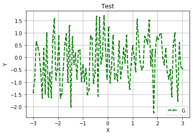

```python
from matplotlib import pyplot as plt

x = np.linspace(-3, 3, 100)
y1 = np.exp(x)
y2 = np.cos(x)
y3 = np.random.randn(100)

p1 = plt.plot(x, y3, label='test', color='green', marker='o', linestyle='dashed',
         linewidth=2, markersize=2)

p1[0].set_label('test')
plt.xlabel("X")
plt.ylabel("Y")
plt.title("Test")

plt.legend(handles=p1, labels='G', loc='lower right')
plt.grid(1)
plt.axis('on')
plt.show()

# print(dir(plt))
```

### 2.2: Figure object and plotting properties

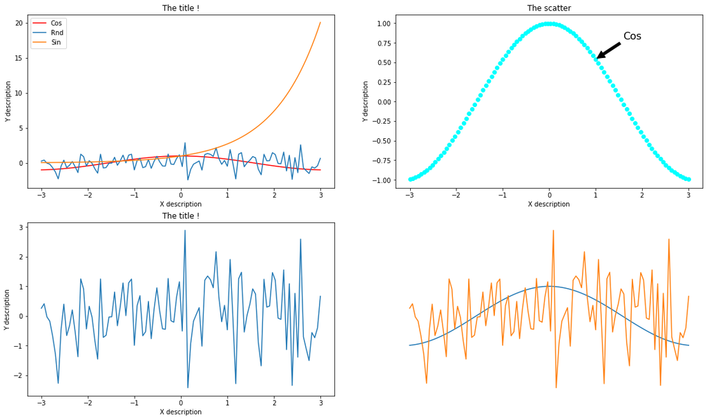

```python
fig, ax = plt.subplots(nrows=2, ncols=2) # number of subplots
fig.set_figwidth(19) # figure width in cm
fig.set_figheight(11) # figure height in cm


ax[0, 0].plot(x, y2, label='Cos', color='red') # plotting with specs
ax[0, 0].plot(x, y3, label='Rnd') # colors, scatters and ...
ax[0, 0].plot(x, y1, label='Sin')
ax[0, 1].scatter(x, y2, label='Cos', color='cyan')
ax[1, 0].plot(x, y3, label='Rnd')
ax[1, 1].plot(x, y2, label='Cos')
ax[1, 1].plot(x, y3, label='Rnd')


ax[0, 1].annotate('Cos', (1, np.cos(1)),
            xytext=(0.8, 0.9), textcoords='axes fraction',
            arrowprops=dict(facecolor='black', shrink=0.05),
            fontsize=16,
            horizontalalignment='right', verticalalignment='top') # annotation cursor


ax[0, 0].set_title("The title !")
ax[0, 0].set_xlabel("X description")
ax[0, 0].set_ylabel("Y description")

ax[1, 0].set_title("The title !")
ax[1, 0].set_xlabel("X description")
ax[1, 0].set_ylabel("Y description")

ax[0, 1].set_title("The scatter")
ax[0, 1].set_xlabel("X description")
ax[0, 1].set_ylabel("Y description")

ax[1, 1].grid('on')
ax[1, 1].axis('off')

ax[0, 0].legend()
fig.show()
```

# 3: Introduction to object-oriented python

### 3.1: Classes

In this course, we usually use object-oriented programming tools.

here, we have an example of two classes with inheritance, static method and submethods, keywords in function inputs.

```python
from matplotlib import pyplot as plt
import numpy

class plotter:

    def __init__(self, rows, cols, width, height):
        self.fig, self.ax = plt.subplots(nrows=rows, ncols=cols)
        self.fig.set_figwidth(width)
        self.fig.set_figwidth(height)
        return

    @staticmethod
    def plot(ax, x, y, title="", x_label="", y_label="", grid='on', axis='on'):
        ax.plot(x, y)
        ax.set_title(title)
        ax.set_xlabel(x_label)
        ax.set_ylabel(y_label)

        ax.grid(grid)
        ax.axis(axis)
        return

class painter(plotter): # inheritance from plotter class

    def __init__(self, boom_width, boom_height, width=21, height=12):
        super().__init__(rows=1, cols=1, width=width, height=height)
        self.boom_width = boom_width
        self.boom_height = boom_height
        return

    def sinusy(self, x):
        self.ax.plot(x, np.sin(x))
        return

    def exponenty(self, x):
        self.ax.plot(x, np.exp(x))
        return

    def free_draw(self, x, y):
        self.ax.plot(x, y)
        print("The rawing")
        return
```

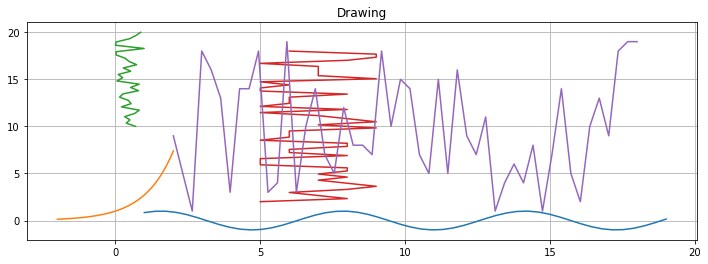

```python
msr = painter(100, 100)
msr.sinusy(x=np.linspace(1, 19, 50))
msr.exponenty(x=np.linspace(-2, 2, 60))

msr.plot(ax=msr.ax, x=np.random.rand(30), y=np.linspace(10, 20, 30), title="Drawing")
msr.plot(ax=msr.ax, x=np.random.randint(5, 10, 50), y=np.linspace(2, 18, 50), title="Drawing")
msr.plot(ax=msr.ax, x=np.linspace(2, 18, 50), y=np.random.randint(1, 20, 50), title="Drawing")
```

# 4. Signals

### 4.1: Definition and plotting signals

Example : Define two signals and plot them

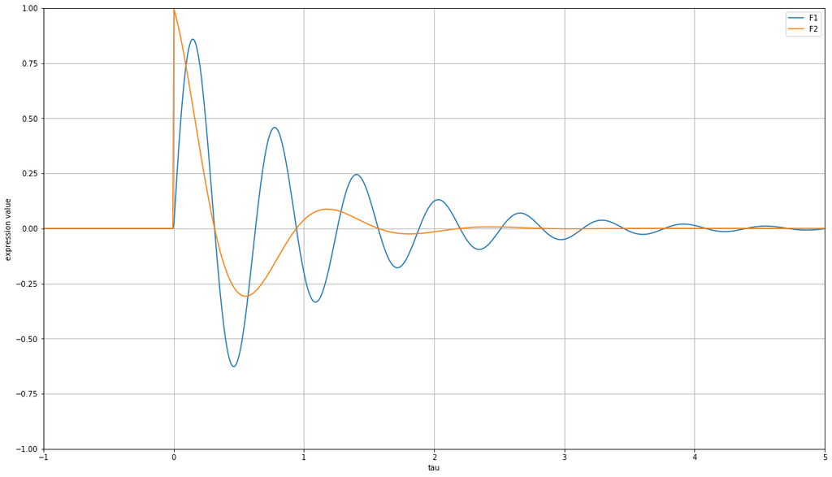

```python
import numpy as np
import matplotlib.pyplot as plt

u = lambda x : (np.sign(x) + 1)/2
f1 = lambda x : (np.exp(-x) * np.sin(10*x)) * u(t)
f2 = lambda x : (np.exp(-2*x) * np.cos(5*x)) * u(t)

t = np.linspace(-2, 6, 1000)
fig, ax = plt.subplots(1, 1)
fig.set_figwidth(19)
fig.set_figheight(11)

p1 = ax.plot(t, f1(t))
p2 = ax.plot(t, f2(t))
p1[0].set_label('F1')
p2[0].set_label('F2')

ax.legend(loc='upper right')
ax.set_xlabel("tau")
ax.set_ylabel("expression value")
ax.grid(True)

ax.set_ylim(ymin=-1, ymax=1)
ax.set_xlim(xmin=-1, xmax=5)
fig.show()
```

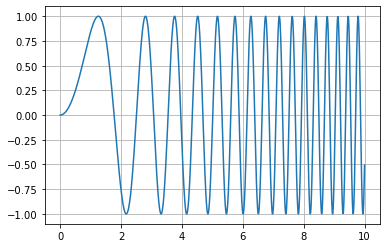

```python
from matplotlib.pyplot import *
import numpy as np

x = np.linspace(0, 10, 1000)
y = np.sin(x**2)

plot(x, y)
axis('on')
grid('on')
show()
```

### 4.2: Signal computations

Integration, derivation

#### 4.2.1: Derivative

example: symbolic derivation :

$$ f^{\prime}_{(t)} = \dfrac{\partial f_{(t)}}{\partial t} = diff(f, t, 1)$$

```python
from sympy import * # imports all required functions, methods and types

x, y, z, t = symbols('x y z t') # symbols

f1 = cos(-t) + sin(2*t) + t**3 * exp(-3*t)
fd1 = diff(f1, t, 1) # First order derivative

print("\n First function:")
print(fd1)
print(fd1.subs(t, 3)) # string output
print(fd1.subs(t, 27.76275)) # float output

f2 = sin(x + y) + x*y**3 + x*y**4
fd2 = diff(diff(f2, y, 1), x, 1) # second-order derivative based on y
print("\n Second function:")
print(fd2)
print(fd2.subs(x, 2.).subs(y, 1.)) # getting values from the function
```

```
 First function:
-3*t**3*exp(-3*t) + 3*t**2*exp(-3*t) - sin(t) + 2*cos(2*t)
-sin(3) - 54*exp(-9) + 2*cos(6)
0.551769145867537

 Second function:
4*y**3 + 3*y**2 - sin(x + y)
6.85887999194013
```

#### 4.2.2: Integration

example: symbolic integration :

$$ \int^{t}_{-\infty} f_{(t)} d t = integrate(f, t) $$

```python
from sympy import * # imports all required functions, methods and types

x, y, z, t = symbols('x y z t') # symbols

f1 = cos(-t) + sin(2*t) + t**3 * exp(-3*t)
fd1 = integrate(f1, t) # First order derivative

print("\n First function:")
print(fd1)
print(fd1.subs(t, 3)) # string output
print(fd1.subs(t, 27.76275)) # float output

f2 = sin(x + y) + x*y**3 + x*y**4
fd2 = integrate(integrate(f2, y), x) # second-order derivative based on y
print("\n Second function:")
print(fd2)
print(fd2.subs(x, 2.).subs(y, 1.)) # getting values from the function
```

```
 First function:
(-9*t**3 - 9*t**2 - 6*t - 2)*exp(-3*t)/27 + sin(t) - cos(2*t)/2
-cos(6)/2 - 344*exp(-9)/27 + sin(3)
0.229226932445039

 Second function:
x**2*y**5/10 + x**2*y**4/8 - sin(x + y)
0.758879991940133
```

#### 4.2.3: Convolution

example: symbolic convolution :

```python
from sympy import *


def convolve(f, g, t):
    tau = Symbol('tau')
    return integrate(f.subs(t, tau) * g.subs(t, t - tau), tau)


t = Symbol('t')
f1 = exp(-t) * Heaviside(t)
f2 = Heaviside(t)
f3 = convolve(f1, f2, t)

print(f3)
```

```
(-(1 - exp(-t))*Heaviside(t) + (1 - exp(-tau))*Heaviside(tau))*Heaviside(t - tau)
```

#### 4.2.4: Numerical differentiation

```python
import numpy as np

x = np.random.randint(-3, 3, 10)
y1 = np.gradient(x, 1) # the interpolated gradient
y2 = x[0:len(x)-1] - x[1:len(x)] # normal gradient

print(x)
print(y1)
print(y2)
```

```
[-2  1 -3  2  0  2 -2 -3  0  2]
[ 3.  -0.5  0.5  1.5  0.  -1.  -2.5  1.   2.5  2. ]
[-3  4 -5  2 -2  4  1 -3 -2]
```

### 4.3: Integral Transforms

#### 4.3.1 Laplace transform

```python
from sympy.integrals import laplace_transform
from sympy.abc import t, s, a

F1 = t**2 + sin(t) + exp(3*t)
F2 = t + cos(t)
L1 = laplace_transform(F1, t, s)
L2 = laplace_transform(F2, t, s)
L3 = L1[0]*L2[0]

print(L1, L2, L3)
```

```
(1/(s**2 + 1) + 1/(3*(s/3 - 1)) + 2/s**3, 3, Ne(s/3, 1)) ((s**3 + s**2 + 1)/(s**4 + s**2), 0, True) (s**3 + s**2 + 1)*(1/(s**2 + 1) + 1/(3*(s/3 - 1)) + 2/s**3)/(s**4 + s**2)
```

#### 4.3.2: Inverse Laplace transform

```python
from sympy.integrals.transforms import inverse_laplace_transform
from sympy import exp, Symbol
from sympy.abc import s, t
a = Symbol('a', positive=True)

# F3 = inverse_laplace_transform(L3, s, t)
L4 = exp(-a*s)/s**2
F4 = inverse_laplace_transform(L4, s, t)

print(F4)
```

```
(-a + t)*Heaviside(-a + t)
```

#### 4.3.3: Mellin transform

```python
from sympy.integrals.transforms import mellin_transform
from sympy import exp
from sympy.abc import x, s

F1 = exp(-x) + sin(x)
M1 = mellin_transform(F1, x, s)
print(M1)
```

```
((2**s*sqrt(pi)*gamma(s/2 + 1/2) - gamma(-s/2)*gamma(s + 1))/(2*gamma(1 - s/2)), (0, 1), True)
```

#### 4.3.4: Fourier and I-Fourier transform

```python
from sympy import fourier_transform, exp, inverse_fourier_transform
from sympy.abc import x, k

F1 = exp(-x*2) * Heaviside(x)
Q1 = fourier_transform(F1, x, k)
Q2 = fourier_transform(F2, x, k, noconds=False)
F2 = inverse_fourier_transform(Q1, k, x)

print(Q1)
print(Q2)
print(F2.simplify())
```

[output not shown]

# 5. Differential equations

## 5.1 Definition

In python-sympy, to start a DE session, at first we need to assign differential equations.

Look at this simple example:

```python
from sympy import Function, dsolve, Eq, Derivative, sin, cos, symbols
from sympy.abc import x

f = Function('f')(x) # Defining F as function of x
fp = Derivative(f, x) # F prime (1st derivative)
fz = Derivative(f, x, x) # F zegond (2nd derivative)
fy = Derivative(fz, x)

deq1 = fz + 9*f
p1 = dsolve(deq1, f)

print(p1)
```

```
Eq(f(x), C1*sin(3*x) + C2*cos(3*x))
```

# 6. Discrete signals

# 7. State-space equations

# 8. Transfer functions

# 9. LTI system

# 10. Filters

# 11. Block diagrams

# 12. Control systems